# R Notebook

12/5/2019

Topic: Our topic for this final project is the financial analysis of the oil industries stocks. We decided to do this topic because we think that it is a a good challenge and we will be able to implement the techniques we learned in this class. Both of us follow the stock market and we thought that doing an analysis of the oil industry would be very interesting. The stocks prices within the oil industry is very hecktic and uncertain. We wanted to see if we could find out what kind factors influence the rise and fall of the market. There are many aspects within the oil industry that influence the stock price and we would like to look at many of them.

Overarching Research Question: How have Oil&Gas Companies, such as ExxonMobil and Haliburton, been performing in recent years?

Research Questions: - Have the performance of Oil & Gas stocks been performing better than the market? - Why are some oil & gas companies doing better than others? - What influences oil companies to do good or bad in the stock market? - How does the the stock of service companies correspond compared to how well or how bad oil companies do in the market? - How does the price of oil compared to the price of the stock? - How do accidents affect the stock of oil companies.

Here, we establish which packages we are importing:

```r
library(readr)
library(DataComputing)
library(dplyr)
library(tidyverse)
library(lubridate)
library(readr)
library(ggplot2)
library(zoo)
```

This block is used to import the various tables that are used in our report:

```r
CVX <- read_csv("CVX.csv")
head(CVX)
```

| Date | Open | High | Low | Close | Adj Close | Volume |
| --- | --- | --- | --- | --- | --- | --- |
| 2014-12-05 | 111.79 | 112.29 | 110.71 | 110.87 | 90.35990 | 7663400 |
| 2014-12-08 | 109.89 | 109.94 | 106.41 | 106.80 | 87.04282 | 13809000 |
| 2014-12-09 | 106.17 | 108.15 | 106.13 | 107.01 | 87.21397 | 11053000 |
| 2014-12-10 | 106.22 | 106.25 | 103.07 | 104.86 | 85.46170 | 15073400 |
| 2014-12-11 | 104.97 | 107.27 | 104.30 | 104.91 | 85.50246 | 10293600 |
| 2014-12-12 | 103.76 | 104.35 | 102.37 | 102.38 | 83.44048 | 12013600 |

```r
CVX <-
  CVX %>%
  mutate(weekma = rollmean(Close, k = 21, fill = NA)) %>%
  mutate(tweekma = rollmean(Close, k = 100, fill = NA))

HAL <- read_csv("HAL.csv")
head(HAL)
```

| Date | Open | High | Low | Close | Adj Close | Volume |
| --- | --- | --- | --- | --- | --- | --- |
| 2014-12-05 | 40.81 | 41.02 | 40.03 | 40.37 | 36.27629 | 30049700 |
| 2014-12-08 | 39.84 | 39.95 | 38.38 | 38.59 | 34.67679 | 37381000 |
| 2014-12-09 | 38.04 | 39.69 | 37.87 | 39.50 | 35.49452 | 33268800 |
| 2014-12-10 | 38.47 | 39.20 | 37.84 | 38.12 | 34.25445 | 35185800 |
| 2014-12-11 | 38.06 | 39.13 | 38.03 | 38.23 | 34.35329 | 22655600 |
| 2014-12-12 | 37.81 | 38.48 | 37.46 | 37.93 | 34.08372 | 30147100 |

```r
XOM <- read_csv("XOM.csv")
head(XOM)
```

| Date | Open | High | Low | Close | Adj Close | Volume |
| --- | --- | --- | --- | --- | --- | --- |
| 2014-12-05 | 93.95 | 94.59 | 93.35 | 93.82 | 77.33820 | 11831900 |
| 2014-12-08 | 92.90 | 93.13 | 91.37 | 91.70 | 75.59062 | 15735900 |
| 2014-12-09 | 91.23 | 92.06 | 90.76 | 91.38 | 75.32684 | 15883800 |
| 2014-12-10 | 90.72 | 90.73 | 88.20 | 88.67 | 73.09293 | 22279400 |
| 2014-12-11 | 88.86 | 91.54 | 88.85 | 89.20 | 73.52982 | 21522200 |
| 2014-12-12 | 88.71 | 89.00 | 86.60 | 86.60 | 71.38658 | 24568300 |

```r
SP <- read_csv("GSPC.csv")

BrentOilPrices <- read_csv("BrentOilPrices.csv")

#database <- read_csv("database.csv")

#use_ng_capita <- read_csv("use_ng_capita.csv")


BrentOilPrices <-
  BrentOilPrices %>%
  mutate(Date = mdy(Date))

beatingSP <- function(stock, index) {
  adjustS <- 2790.37/120.67
  if(tail(stock$Close,1)*adjustS>tail(index$Close,1)) {
    print("This stock is outperforming the index")
  }
  else{
    print("The stock is not beating the index")
  }
}
```

Lets take a look at Chevron, to get an idea of where the stock is at over the past 5 years, overlayed with a 3 week and 100 day rolling centered average.

```r
na.omit(CVX)
```

| Date | Open | High | Low | Close | Adj Close | Volume | weekma | tweekma |
| --- | --- | --- | --- | --- | --- | --- | --- | --- |
| 2015-02-18 | 111.25 | 111.65 | 110.37 | 110.44 | 90.89375 | 6920300 | 108.81810 | 107.5246 |
| 2015-02-19 | 108.20 | 109.58 | 107.24 | 108.35 | 89.17364 | 9721100 | 108.58952 | 107.5063 |
| 2015-02-20 | 108.43 | 108.87 | 107.50 | 108.60 | 89.37940 | 7610600 | 108.36095 | 107.5215 |
| 2015-02-23 | 107.79 | 108.50 | 107.35 | 107.86 | 88.77037 | 6724000 | 108.10572 | 107.5314 |
| 2015-02-24 | 107.89 | 108.24 | 107.34 | 107.96 | 88.85268 | 5708400 | 107.78667 | 107.5623 |
| 2015-02-25 | 108.12 | 108.78 | 107.76 | 108.58 | 89.36295 | 4806500 | 107.45857 | 107.5889 |
| 2015-02-26 | 107.89 | 107.92 | 106.60 | 107.06 | 88.11197 | 5903100 | 107.08905 | 107.6516 |
| 2015-02-27 | 107.52 | 107.73 | 106.57 | 106.68 | 87.79922 | 6396500 | 106.69095 | 107.7166 |
| 2015-03-02 | 106.32 | 106.34 | 104.93 | 105.90 | 87.15726 | 7343700 | 106.32286 | 107.7752 |
| 2015-03-03 | 105.88 | 106.22 | 104.81 | 105.16 | 86.54823 | 6901200 | 105.86524 | 107.7920 |

[output cut: 990 more lines]

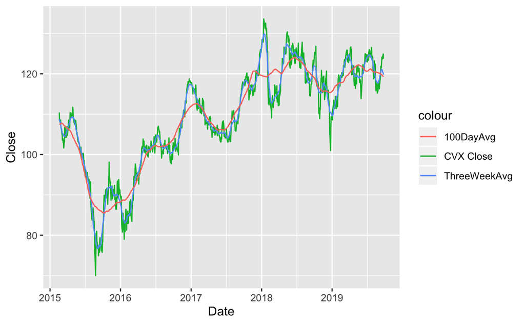

```r
ggplot(data = na.omit(CVX)) + geom_line(aes(x = Date, y = Close, color = "CVX Close")) +
  geom_line(aes(x=Date, y = weekma,color = "ThreeWeekAvg")) + geom_line(aes(x=Date, y = tweekma,color = "100DayAvg"))
```

Use of function to check if a given stock is beating the S&P 500

```r
beatingSP(CVX, SP)
```

```
[1] "The stock is not beating the index"
```

This graph describes how a few oil/gas companies (CVX - Chevron, HAL - Haliburton) are performing when compared to the S&P 500 (SP):

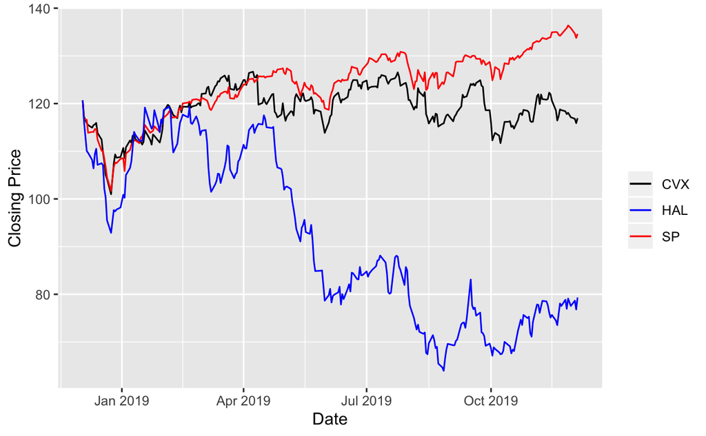

```r
adjustS <- 2790.37/120.67
adjustH <- 32.66/120.67
combined <-
CVX %>%
inner_join(HAL, by=c("Date"="Date")) %>%
inner_join(SP, by=c("Date"="Date")) %>%
filter(Date>="2018-12-01") %>%
mutate(CVX = Close.x) %>%
mutate(SP= Close/adjustS) %>%
mutate(HAL = Close.y/adjustH) %>%
select(Date, CVX, SP, HAL)
g <- ggplot(data = combined) + geom_line(aes(x = Date, y=CVX, color = "CVX")) +
geom_line( aes(x=Date, y = combined$SP,color = "SP")) +
geom_line(aes(x=Date, y = combined$HAL,color = "HAL")) + ylab("Closing Price") + scale_colour_manual(name='', values=c('SP'= "red",
'HAL'='blue', "CVX"="black"))
g
```

This graph is used to compare the performance of HAL stock against a basic oil index:

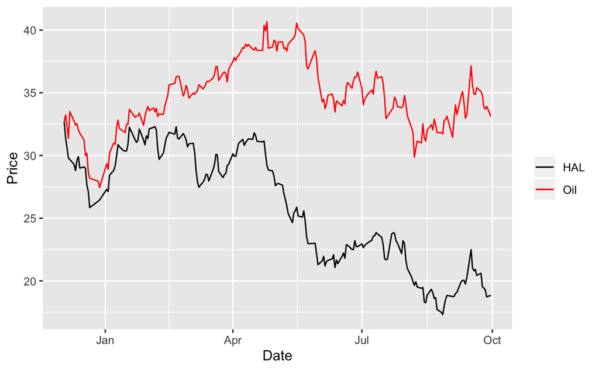

```r
adjustO <- 60.17/32.66
combined2 <-
HAL %>%
inner_join(BrentOilPrices, by=c("Date"="Date")) %>%
filter(Date>="2018-12-01") %>%
mutate(HAL = Close) %>%
mutate(Oil= Price/adjustO) %>%
select(Date, HAL, Oil)

g <- ggplot(data = combined2) + geom_line(aes(x = Date, y = HAL, color = "HAL")) +
geom_line(aes(x=Date, y = Oil, color = "Oil")) + ylab("Price") + scale_colour_manual(name='', values=c('Oil'= "red", "HAL"="black"))
g
```

This graph is used to compare the performance of CVX stock against a basic oil index:

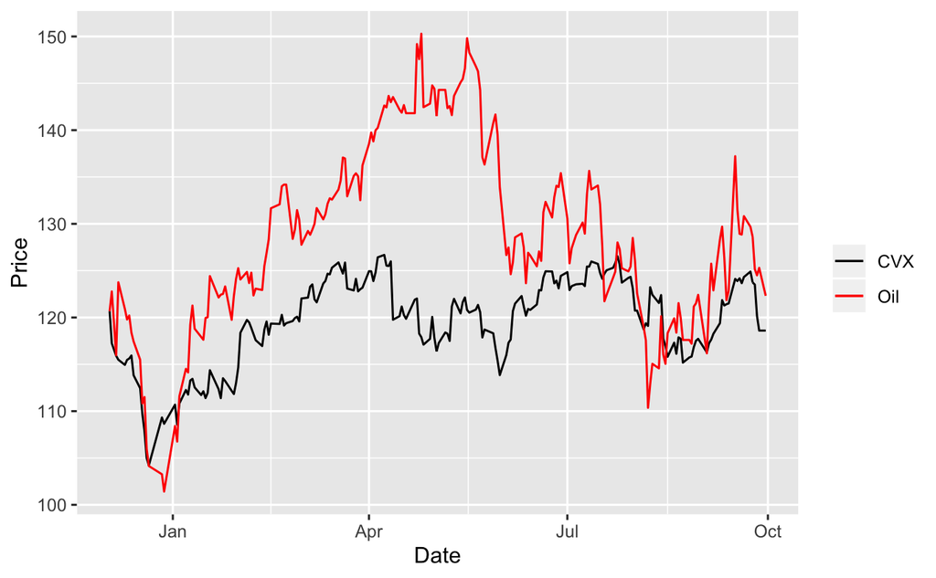

```r
adjustO <- 60.17/120.67
combined3 <-
CVX %>%
inner_join(BrentOilPrices, by=c("Date"="Date")) %>%
filter(Date>="2018-12-01") %>%
mutate(CVX = Close) %>%
mutate(Oil= Price/adjustO) %>%
select(Date, CVX, Oil)
g <- ggplot(data = combined3) + geom_line(aes(x = Date, y = CVX, color = "CVX")) +
geom_line(aes(x=Date, y = Oil, color = "Oil")) + ylab("Price") + scale_colour_manual(name='', values=c('Oil'= "red", "CVX"="black"))
g
```

This graph is used to compare the performance of XOM (ExxonMobil) stock against a basic oil index:

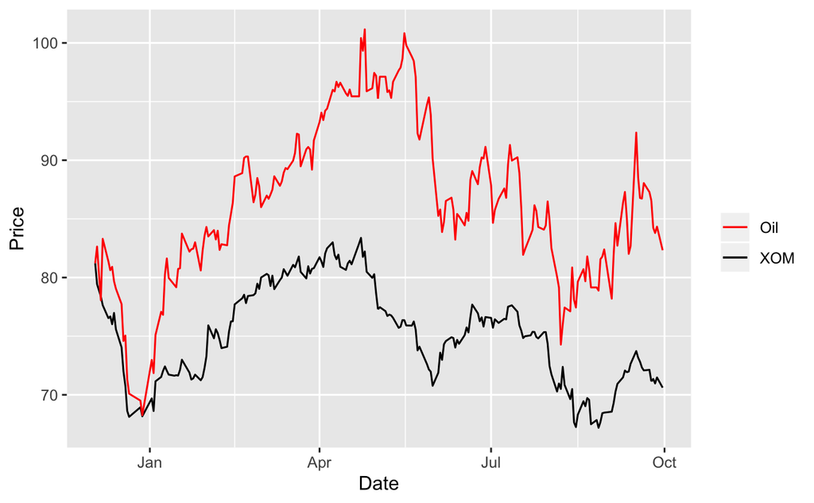

```r
adjustO <- 60.17/81.22
combined4 <-
XOM %>%
inner_join(BrentOilPrices, by=c("Date"="Date")) %>%
filter(Date>="2018-12-01") %>%
mutate(XOM = Close) %>%
mutate(Oil= Price/adjustO) %>%
select(Date, XOM, Oil)
g <- ggplot(data = combined4) + geom_line(aes(x = Date, y = XOM, color = "XOM")) +
geom_line(aes(x=Date, y = Oil, color = "Oil")) + ylab("Price") + scale_colour_manual(name='', values=c('Oil'= "red", "XOM"="black"))
g
```

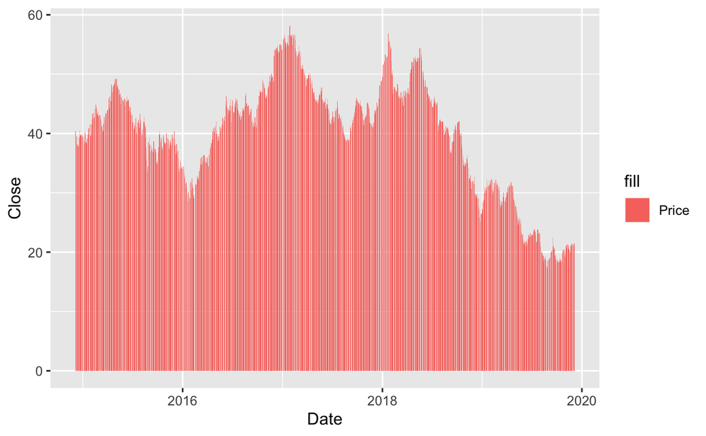

```r
ggplot(data = HAL, aes(x = Date, y = Close, fill = "Price")) + geom_bar(stat = "identity")
```

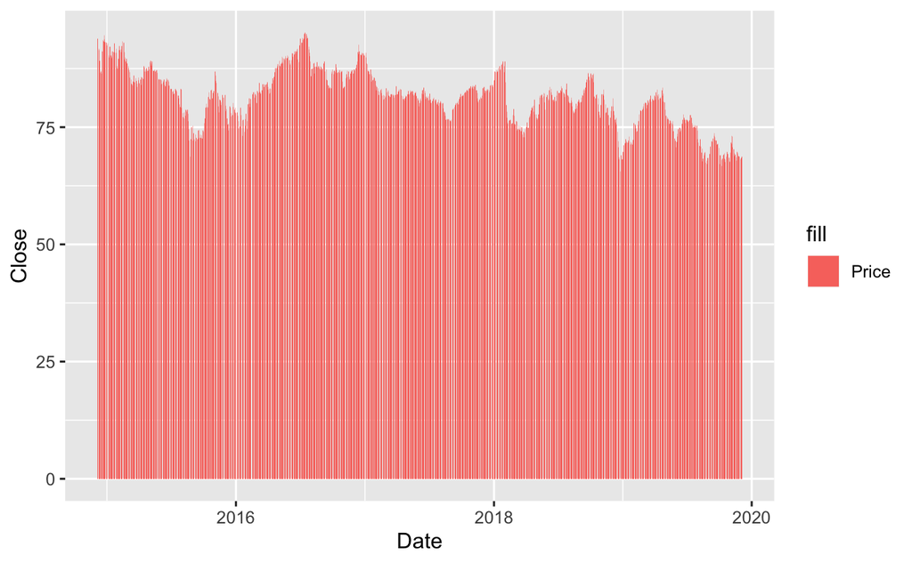

```r
ggplot(data = XOM, aes(x = Date, y = Close, fill = "Price")) + geom_bar(stat = "identity")
```

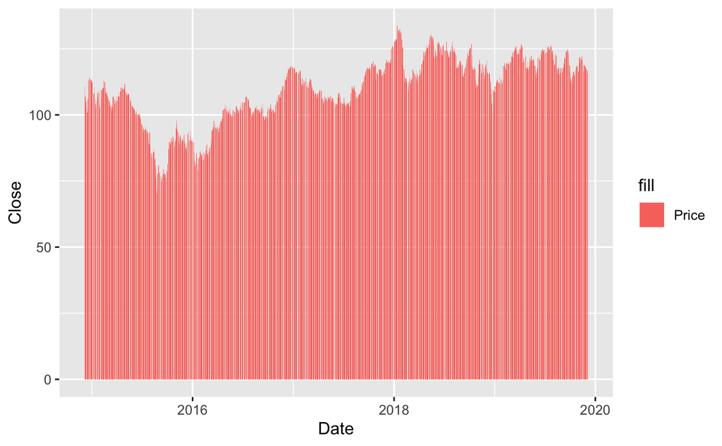

```r
ggplot(data = CVX, aes(x = Date, y = Close, fill = "Price")) + geom_bar(stat = "identity")
```

## Conclusion

In conclusion, we have found that, at least in the companies we examined, that Oil and Gas companies have seen slower growth compared to the main oil index, and when compared to a general market index such as the S&P 500. This could be due to many reasons, such as falling gas prices and low demand, paired with a high supply. Yet, we see even the gas index beating out these companies.